# Wordy Rappinghood

An exploration of modern machine learning techniques on music metadata.

*Alain-Parviz Soltani*

*Code for this article is available [here](https://github.com/alsoltani/wordy-rappinghood).*

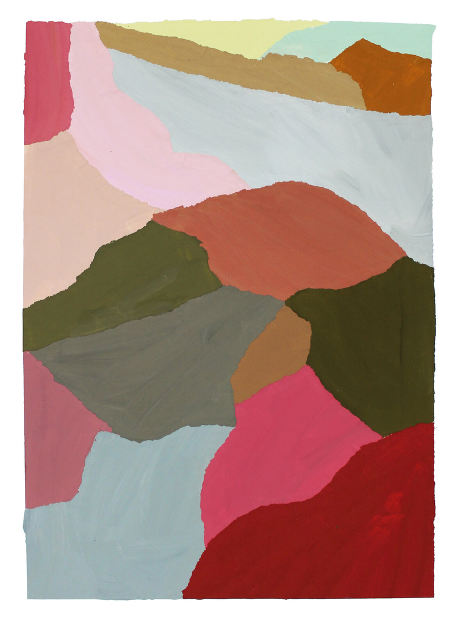

Clare Dudeney, Lost Words, 2023

*“Mots pressés, mots sensés, mots qui disent la vérité, mots maudits, mots mentis, mots qui manquent le fruit d’esprit”*.

Those prescient words about large language models’ achievements are not the result of a savvy and thorough technical analysis; they’re taken from 1981 new-wave-hit “Wordy Rappinghood” by Tom Tom Club (founded by Tina Weymouth et Chris Frantz who, along with David Byrne, formed Talking Heads; another great tagline for LLMs — but I digress.)

Today, we’re gonna stay in the music realm, and observe what LLMs are capable of when it comes to semantic search and information retrieval.

1. Our dataset
2. Vectors floating through space
3. Loading up the data
4. Taking songs somewhere new

# Our dataset

We’ll work with the Free Music Archive (FMA) repository. It’s an open source dataset useful on tasks such as information retrieval; let’s dig into the data.

From the creators of the dataset themselves, here’s a brief description of the data we’ll use:

- `tracks.csv`: per track metadata such as ID, title, artist, genres, tags and play counts, for all 106,574 tracks.
- `genres.csv`: all 163 genres with name and parent (that we won’t use today).

There’s much more available here, including audio features computed with `librosa`, but we’ll stick to text for now.

By simpling glancing at the data, we can see that some text fields are sparsely filled (something that theoretically shouldn’t be an issue with semantic search), and that some genres are decidedly more represented than others.

[figure not shown]

# Vectors floating through space

> *Recommended listen: [Lonnie Liston Smith – Floating Through Space (Loveland, 1978)](https://youtu.be/_kmHS-IndZw)*

We’ll start by implementing vector search; as opposed to more traditional lexical search, its goal is to compare textual objects in a larger dimensional space, where non-intuitive connections and similarities could be found. It’s also at the heart of *Retrieval Augmented Generation (RAG)*, a popular technique to make your LLM sample conditionally to pre-existing documents.

In this new space, items are represented by vectors, called *embeddings*; given a good mapping towards this high-dimensional space and a meaningful distance, we could find relevant objects by picking the closest neighbours to our query input.

We’ll use cosine similarity to compare our embeddings, $T$ being defined as the target embedding, and $Q$ the query input counterpart:

$$S_C (T, Q) = \cos(\theta) = {\mathbf{T} \cdot \mathbf{Q} \over
\|\mathbf{T}\| \|\mathbf{Q}\|} = \frac{ \sum\limits_
{i=1}^{n}{T_i Q_i} }{ \sqrt{\sum\limits_{i=1}^{n}{T_i^2}} \cdot
\sqrt{\sum\limits_{i=1}^{n}{Q_i^2}} }$$

Notably, this computes the angle between the two vectors, and disregards magnitude: this is important, as clear-cut, short content can be as semantically meaningful as a lengthy piece of prose describing the same concept.

Embeddings are generally produced by the encoder block of a [Transformer](https://huggingface.co/learn/nlp-course/en/chapter1/4); for text data, we’ll use BERT-based Transformers that turn sentences into vector embeddings.

`SentenceTransformers` is a great library, built on top of Hugging Face’s `transformers`, that gives us access to many classical pre-trained models. In this blog post, we’ll use `all-MiniLM-L6-v2`, a tiny model that offers a great trade-off between [semantic performance and size](https://sbert.net/docs/sentence_transformer/pretrained_models.html).

# Loading up the data

> *Recommended listen: [NOW Ensemble – City Boy (Dreamfall, 2015)](https://youtu.be/9potE63cml8)*

Let’s now build our vector search database.

First up, we’ll clean up the `tracks` data — attributing genres by joining the aforementioned table to it, and stripping unwanted HTML attributes, etc. — and we’ll load it up into a database capable of performing vector search similarity ( VSS).

Some databases already offer such features (e.g. `pg_vector` for PostgreSQL), while others are currently being implemented (see Alex Garcia’s [wonderful SQLite extension](https://alexgarcia.xyz/blog/2024/building-new-vector-search-sqlite/index.html)). Here, I used DuckDB, which recently released an experimental extension aptly-named `vss`, capable of performing semantic search by way of [Hierarchical Navigable Small World (HNSW) graphs](https://www.pinecone.io/learn/series/faiss/hnsw/), which offers great efficiency in such case.

Speaking of optimizations, we’ll try to be mindful of memory and throughput as much as we can here. We’ll send Pandas data in chunks through a generator to control memory usage, and make use of DuckDB’s optimizations to preserve row-to-row overhead, such as reading from JSON objects.

To create the vector table, you’ll only need the following lines:

```
CREATE TABLE IF NOT EXISTS embeddings (
    track_id INTEGER PRIMARY KEY,
    vector FLOAT[N_EMBED] -- embedding size: depends on your model
);

/* Manually load vector similarity search.
Allow persistence of HNSW index to use outside of in-memory dbs.*/
INSTALL vss;
LOAD vss;
SET hnsw_enable_experimental_persistence = TRUE;
CREATE INDEX IF NOT EXISTS cos_index ON embeddings USING HNSW (vector)
WITH (metric = 'cosine');
```

(**Note**: WAL recovery hasn’t been properly implemented as of now for HNSW-indexed tables, hence the persistence flag; you might want to wait a little before putting this into production.)

We’ll store both the structured and embedded data in two different tables (`tracks` and `embeddings`). As encoding our embeddings amounts to a forward pass on the encoder portion of our model, the operation can be a tad intensive depending on the size of our input.

To distribute encoding across several GPUs/CPUs, we can set a `pool` at the initialization of our process, and make use of method `start_multi_process_pool`:

```
class VectorSearch:
    def __init__(self, model_name: str, chunksize: int = CHUNK_SIZE):
        ...

        self.model = SentenceTransformer(model_name)
        self.pool = self.model.start_multi_process_pool()

    def encode_database(self):
        ...

        for chunk in track_generator:
            # Clean data, and concatenate it as a sentence
            processed = self.processor.process_tracks(chunk, genre_titles)
            encoder_input = self.processor.create_encoder_input(processed)

            # Compute the embeddings
            embeddings = self.model.encode_multi_process(
                encoder_input.tolist(),
                self.pool,
                chunk_size=self.model_chunksize
            )
            ...

            # Load these in DuckDB
            self.client.insert_tracks(processed)
            self.client.insert_embeddings(embedding_frame)

        self.model.stop_multi_process_pool(self.pool)
```

To test my solution and make use of GPUs comes encoding time, I deployed a pod on [RunPod](https://www.runpod.io) with 2 x RTX 4090 GPUs (at $0.74/hr, they’re pretty cost-effective), 25 vCPU and 200 GB of RAM.

The entire process takes about 8.8 seconds per batch of 10,000 rows (`UPSERT` times are of the same order of magnitude, as we rely on DuckDB data ingestion optimizations).

To put it into perspective, the CPU-only performance on a M-series MacBook Pro with 4P + 4E cores is 98.3 per batch, or ~18 minutes total. Not bad!

We can now perform vector search on our database:

```
def search(self, query_input: str, n_results: int = 5):
    """
    Return k best results for input query.
    """
    embedding = self.model.encode_multi_process(
        [query_input], self.pool, chunk_size=self.model_chunksize
    )
    return self.client.get_nearest_tracks_info(embedding.ravel(), n_results)
```

# Results

Let’s now try our search engine on a few different queries:

*Japanese Funk*

| ID | Artist | Song | Genres |
| --- | --- | --- | --- |
| 43493 | Tsuyoshi Shimokura | FunkOsaka | Funk, Chip Music, Skweee |
| 43492 | hally feat. Seiko Kobuchi | utabism - a synthesizer boy | Funk, Chip Music, Skweee |
| 43488 | Keishi Yonao | Crush Roll | Funk, Chip Music, Skweee |
| 43495 | Utabi Hirokawa | Stop and Go (Ubiktune edit) | Funk, Chip Music, Skweee |
| 34516 | Gorowski | Wok The Funk | Electronic, Techno, Dance |

*Classical Music*

| ID | Artist | Song | Genres |
| --- | --- | --- | --- |
| 11733 | Michael Hawley | Sonata ‘Waldstein’, Op. 53 - II. Introduzione-Adagio molto | Classical |
| 11734 | Michael Hawley | Sonata ‘Waldstein’, Op. 53 - III. Rondo-Allegretto moderato | Classical |
| 11736 | Michael Hawley | Sonata No. 21 in C Major ‘Waldstein’, Op. 53 - I. Allegro con brio | Classical |
| 11738 | Free Tim | Schubert’s Ave Maria | Classical |
| 11750 | Free Tim | Vivaldo’s Spring from the Four Seasons-Allegro | Classical |

*Avant-Gardist Research*

| ID | Artist | Song | Genres |
| --- | --- | --- | --- |
| 138701 | Charles Premier | Gratter sa terre | Experimental, Electroacoustic, Musique Concrete |
| 132461 | G.Las | Vivaransoma | Field Recordings, Experimental, Sound Collage |
| 132469 | G.Las | Oudienieuwe | Field Recordings, Experimental, Sound Collage |
| 47826 | Lezet | Extended Piano Piece 2 (Folk) | Avant-Garde, Experimental, Minimalism |
| 13073 | Per Gardin | Esoteric | Avant-Garde, Jazz, Electronic, Free-Jazz, Improv |

Nice! The ability to pick up experimental cues from the last query and retrieve *musique concrète* songs is definitely a nice touch, and opens up a whole new realm of possibilities for search.

Of course, there are still many cases where lexical search is warranted — and might be the exact option the user is looking for! — so a healthy mix of lexical and semantic searches, with techniques such as [Reciprocal Rank Fusion](https://plg.uwaterloo.ca/~gvcormac/cormacksigir09-rrf.pdf) seems the way to go.

# Taking songs somewhere new

> *Recommended listen: [Floating Points — Silhouette (I, II & III) (Elaenia, 2015)](https://youtu.be/BG0XBnMyXcQ)*

106,574 is a lot of tracks, and we might want a bit of perspective on the set of songs we’re looking at.

So far, we’ve expressed our tracks in a space that allows semantic comparisons; in this representation, data points are of size 384, the size of the final hidden layer of our encoder — which can be much larger if we use a more powerful model: for instance, [NV-Embed-1](https://huggingface.co/nvidia/NV-Embed-v1), the current leader on the [Massive Text Embedding Benchmark](https://huggingface.co/spaces/mteb/leaderboard) on Hugging Face, has an output size of 4096. That’s a lot of features, and the curse of dimensionality is never far away.

At this step, it is natural to perform *dimensionality reduction*: turn our 384-sized embeddings into vectors of lower dimension, while hopefully preserving most of the semantic capabilities we’ve just gained.

[Uniform Manifold Approximation and Projection (UMAP)](https://arxiv.org/abs/1802.03426) is a good candidate for this: it’s great at preserving local structure, and [scales much better](https://pair-code.github.io/understanding-umap/) than comparable algorithms like t-SNE.

From there, we can group these into meaningful clusters, using *density-based clustering*: we’ll search for areas — let’s called these *islands* — of higher density, and anything below a certain level — *sea level*, if you will — will be deemed noise. In practical terms, we’ll get $m$ clusters $C_1, \dots, C_m$ and $C_{m+1} = -1$ will be our background noise.

We’ll use the hierarchical variant of the popular non-parametric `DBSCAN` algorithm [HDBSCAN](https://joss.theoj.org/papers/10.21105/joss.00205), which works well with non-flat geometry and uneven cluster sizes. Icing on the cake, both `UMAP` and `HDBSCAN` have GPU-accelerated implementations provided by the RapidsAI `cuML` library. What’s not to love?

## Our clustering class

The implementation of our clustering class is pretty straighforward, so I’ll gloss over the details. This is inspired by the `DenseClus` library by AWS Labs, which was initially designed to process mixed-type (categorical + numerical) data, and from which I’ll reuse the numerical extracting tools.

```
class Clustering:
    """
    UMAP on textual embeddings + HDBSCAN clustering.
    """
    ...
    def init_models(self, params: Dict[str, Union[float, str]]):
        ...
        # To be called within constructor.
        # If we've got some nice GPUs at hand:
        self.umap = cuUMAP(
            metric="cosine",
            verbose=False,
            **umap_params,
        )
        self.hdbscan = cuHDBSCAN(
            prediction_data=True,
            **hdbscan_params,
        )

    def fit(self, vector_embeddings: pd.DataFrame):
        self.umap.fit(vector_embeddings)
        self.embedding = self.umap.embedding_
        self.hdbscan.fit(self.embedding)
        self.labels = self.hdbscan.labels_
```

We now need to tune and ensure the validity of our model, and there are some important subtleties along the way.

# Fine-tuning our algorithms

> *Recommended listen: [Stereolab — Cybele’s Reverie (Emperor Tomato Ketchup, 1996)](https://youtu.be/HtUceMv3wjk)*

Notoriously, both algorithms are very sensitive to hyperparameter selection:

- UMAP can provide drastically different results depending on:
  - The number of neighbours, `n_neighbors`, controlling the balance between global and local structure preservation
  - The minimal distance that set points apart, `min_dist`
  - The number of dimensions at the end of the embedding, `n_components`.
- HDBSCAN itself is impacted by:
  - The minimal cluster size, `min_cluster_size`
  - The minimal number of samples per cluster, `min_samples`
  - A parameter `cluster_selection_epsilon`, that ensures clusters below such threshold are not split up any further
  - And a final `clustering_selection_method`, indicating how flat clusters are formed from the tree hierarchy.

Most of these parameters are dataset-dependent: how do we want to form clusters? Should we allow for great class imbalance? These are questions that are highly dependent on domain expertise, but for the sake of this post, we’ll just assume we don’t have sufficient domain knowledge to answer these.

Instead, let’s frame it as a generic optimization problem: we’ll try to find the set of hyperparameters that offers us the lowest loss on our training set.

# An all-encompassing loss

Contrary to standard classification problems, it’s hard to define what accuracy means in a clustering setting, as we don’t have access to any *ground-truth* labels.

Ideally, we’d like a loss that assesses the quality of both our manifold and our clustering. We want a final model that:

1. Form manifolds that nicely retain the local structure of our data
2. While providing good separation comes clustering time.

Assuming independence between the two steps of our pipeline, we could devise a composite loss of the following form:
$$l(X) = 1 - Q_{ma}(X, X_e) Q_{cl}(X_e, C)$$

where $X$ is our dataset, $X_e$ the embeddings produced by the manifold, and $C$ the final clusters. $Q_{ma}, Q_{cl} \in [0, 1]$ respectively measure the quality of our embeddings and the clustering itself; these two quantities ought to be maximized by the grid search procedure.

## Embedding Quality

Let’s first introduce the embedding-specific portion of our loss: the *trustworthiness* of our manifold.

Is is defined as[^1]

$$T(X, X_e, k) =\frac{2}{nk (2n - 3k - 1)} \sum^n_{i=1}
\sum_{j \in \mathcal{N}_{i}^{k}} \max(0, (r(i, j) - k))$$

Intuitively, this looks at the $k$ nearest neighbours in the output space, and penalizes any unexpected elements based on their rank $r(i, j)$. Thus a high trustworthiness will ensure you can preserve local information correctly.

## Clustering Quality

To assess the quality of our clustering, we’ll use the *validity index* defined as
$$D(X_e, C) \in [-1, 1]$$

It comes from [this paper](https://www.dbs.ifi.lmu.de/~zimek/publications/SDM2014/DBCV.pdf) and is often referred to as Density-Based Clustering Validity.

It tries to assign high scores to clusters where:

- Points within each cluster are densely packed (*low core distances*)
- Different clusters are well-separated from each other (*high separation*).

It’s a fairly standard evaluation metric of density-based clustering techniques[^2]. We’ll normalize it between 0 and 1.

## Composite Loss

Our final composite loss looks like this:
$$l(X, k) = 1 - T(X, X_e, k) \tilde{D}(X_e, C)$$
with $\tilde{D}$ the normalized DBCV index.

HDBSCAN has a tendency to form one of two huge clusters, and a collection of tiny ones afterward (in relative size). This can be alleviated by preferring `leaf` to `eom` (‘Excess of Mass’) as a clustering selection method.

But from an optimization perspective, we can also add a penalization term to coerce our model into producing more homogenous clusters; we’ll use an entropy-based penalty:

$$l(X, k) = 1 - T(X, X_e, k) \tilde{D}(X_e,
C) + \lambda (1 - S(X))$$

where

$$S(X) = - \sum_i \frac{p_i \log_2
p_i}{\log_2 n}$$
is the normalized Shannon entropy, taken on the output probabilities of our model $p$.

Just like $\ell_1$-regularization can be seen as MAP estimation of a linear regression model with a Laplace prior, this is like choosing a prior based on [Jaynes’ principle of maximum entropy](https://caseychu.io/posts/maximum-entropy-kl-divergence-and-bayesian-inference/).

We’ll use this loss to perform our hyperparameter optimization on.

[^1]: For each sample $i$, $\mathcal{N}_{i}^{k}$ are its $k$ nearest neighbors in the output space, and every sample $j$ is its $r(i, j)$-th nearest neighbor in the input space ($r$ being the rank function in distance between samples $i$ and $j$).
[^2]: Classical clustering scores based on a measure of distance between the clustered observations, such as Silhouette, don’t work in a density-based setting, which is the main reason behind the usage of DBCV. That being said, an extension of Silhouette to such cases has been proposed in [this paper](https://link.springer.com/article/10.1007/s11222-010-9169-0).